# HW: Getting familiar with `ggplot2`

Ethan Bard

Load the `tidyverse` package

```r
library(tidyverse)
```

# Problem 1

You will use the `diamonds` dataset that comes with `ggplot2` (already loaded when you use `library(tidyverse`)). You can explore the dataset by using the function `str()`:

```r
str(diamonds)
```

```
tibble [53,940 x 10] (S3: tbl_df/tbl/data.frame)
 $ carat  : num [1:53940] 0.23 0.21 0.23 0.29 0.31 0.24 0.24 0.26 0.22 0.23 ...
 $ cut    : Ord.factor w/ 5 levels "Fair"<"Good"<..: 5 4 2 4 2 3 3 3 1 3 ...
 $ color  : Ord.factor w/ 7 levels "D"<"E"<"F"<"G"<..: 2 2 2 6 7 7 6 5 2 5 ...
 $ clarity: Ord.factor w/ 8 levels "I1"<"SI2"<"SI1"<..: 2 3 5 4 2 6 7 3 4 5 ...
 $ depth  : num [1:53940] 61.5 59.8 56.9 62.4 63.3 62.8 62.3 61.9 65.1 59.4 ...
 $ table  : num [1:53940] 55 61 65 58 58 57 57 55 61 61 ...
 $ price  : int [1:53940] 326 326 327 334 335 336 336 337 337 338 ...
 $ x      : num [1:53940] 3.95 3.89 4.05 4.2 4.34 3.94 3.95 4.07 3.87 4 ...
 $ y      : num [1:53940] 3.98 3.84 4.07 4.23 4.35 3.96 3.98 4.11 3.78 4.05 ...
 $ z      : num [1:53940] 2.43 2.31 2.31 2.63 2.75 2.48 2.47 2.53 2.49 2.39 ...
```

1. Create a bar-plot using `geom_bar()`, mapping the `clarity` to the `x` aesthetic, and `cut` to the `fill` aesthetic. What do you notice?

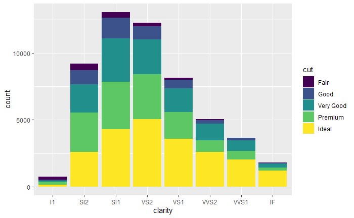

```r
diamonds %>%
  ggplot(aes(x = clarity, fill = cut)) +
  geom_bar()
```

2. What happens if you use the option `position = "fill"` in the plot above?

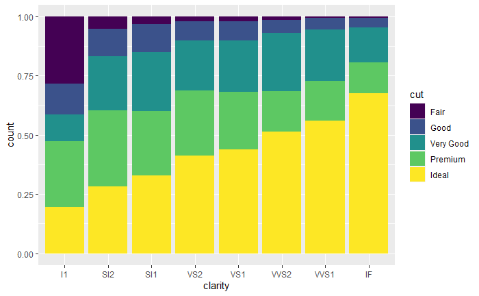

```r
diamonds %>%
  ggplot(aes(x = clarity, fill = cut)) +
  geom_bar(position = "fill")
```

Using the option `position = "fill"`, the bars are viewed as a proportion of total rather than a comparison of frequency. It becomes even more clear that the `ideal` cut is the most popular in this dataset.

# Problem 2

In this problem you will use the `midwest` dataset, also available with the `ggplot2` package. The data comes from the 2000 US Census. Learn more about the `midwest` dataset here

```r
summary(midwest)
```

```
      PID          county             state                area            poptotal         popdensity
 Min.   : 561   Length:437         Length:437         Min.   :0.00500   Min.   :   1701   Min.   :   85.05
 1st Qu.: 670   Class :character   Class :character   1st Qu.:0.02400   1st Qu.:  18840   1st Qu.:  622.41
 Median :1221   Mode  :character   Mode  :character   Median :0.03000   Median :  35324   Median : 1156.21
 Mean   :1437                                         Mean   :0.03317   Mean   :  96130   Mean   : 3097.74
 3rd Qu.:2059                                         3rd Qu.:0.03800   3rd Qu.:  75651   3rd Qu.: 2330.00
 Max.   :3052                                         Max.   :0.11000   Max.   :5105067   Max.   :88018.40
    popwhite          popblack       popamerindian        popasian         popother        percwhite
 Min.   :    416   Min.   :      0   Min.   :    4.0   Min.   :     0   Min.   :     0   Min.   :10.69
 1st Qu.:  18630   1st Qu.:     29   1st Qu.:   44.0   1st Qu.:    35   1st Qu.:    20   1st Qu.:94.89
 Median :  34471   Median :    201   Median :   94.0   Median :   102   Median :    66   Median :98.03
 Mean   :  81840   Mean   :  11024   Mean   :  343.1   Mean   :  1310   Mean   :  1613   Mean   :95.56
 3rd Qu.:  72968   3rd Qu.:   1291   3rd Qu.:  288.0   3rd Qu.:   401   3rd Qu.:   345   3rd Qu.:99.07
 Max.   :3204947   Max.   :1317147   Max.   :10289.0   Max.   :188565   Max.   :384119   Max.   :99.82
   percblack       percamerindan        percasian        percother         popadults          perchsd
 Min.   : 0.0000   Min.   : 0.05623   Min.   :0.0000   Min.   :0.00000   Min.   :   1287   Min.   :46.91
 1st Qu.: 0.1157   1st Qu.: 0.15793   1st Qu.:0.1737   1st Qu.:0.09102   1st Qu.:  12271   1st Qu.:71.33
 Median : 0.5390   Median : 0.21502   Median :0.2972   Median :0.17844   Median :  22188   Median :74.25
 Mean   : 2.6763   Mean   : 0.79894   Mean   :0.4872   Mean   :0.47906   Mean   :  60973   Mean   :73.97
 3rd Qu.: 2.6014   3rd Qu.: 0.38362   3rd Qu.:0.5212   3rd Qu.:0.48050   3rd Qu.:  47541   3rd Qu.:77.20
 Max.   :40.2100   Max.   :89.17738   Max.   :5.0705   Max.   :7.52427   Max.   :3291995   Max.   :88.90
   percollege        percprof       poppovertyknown   percpovertyknown percbelowpoverty percchildbelowpovert
 Min.   : 7.336   Min.   : 0.5203   Min.   :   1696   Min.   :80.90    Min.   : 2.180   Min.   : 1.919
 1st Qu.:14.114   1st Qu.: 2.9980   1st Qu.:  18364   1st Qu.:96.89    1st Qu.: 9.199   1st Qu.:11.624
 Median :16.798   Median : 3.8142   Median :  33788   Median :98.17    Median :11.822   Median :15.270
 Mean   :18.273   Mean   : 4.4473   Mean   :  93642   Mean   :97.11    Mean   :12.511   Mean   :16.447
 3rd Qu.:20.550   3rd Qu.: 4.9493   3rd Qu.:  72840   3rd Qu.:98.60    3rd Qu.:15.133   3rd Qu.:20.352
 Max.   :48.079   Max.   :20.7913   Max.   :5023523   Max.   :99.86    Max.   :48.691   Max.   :64.308
 percadultpoverty percelderlypoverty    inmetro         category
 Min.   : 1.938   Min.   : 3.547     Min.   :0.0000   Length:437
 1st Qu.: 7.668   1st Qu.: 8.912     1st Qu.:0.0000   Class :character
 Median :10.008   Median :10.869     Median :0.0000   Mode  :character
 Mean   :10.919   Mean   :11.389     Mean   :0.3432
 3rd Qu.:13.182   3rd Qu.:13.412     3rd Qu.:1.0000
 Max.   :43.312   Max.   :31.162     Max.   :1.0000
```

1. Create a scatterplot showing the relationship between the variables `area` (in the horizontal axis) and `poptotal` (in the vertical axis)

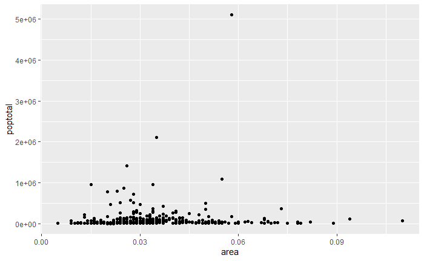

```r
midwest %>%
  ggplot(aes(x = area, y = poptotal)) +
  geom_point()
```

2. Color your points based on the variable `state` (information on 5 different states is included in this dataset). Additionally, size your points based on the variable `popdensity`. Do any points stand out from the rest?

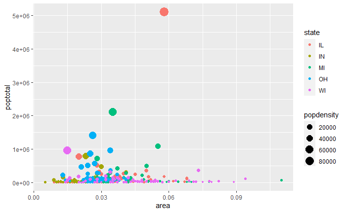

```r
midwest %>%
  ggplot(aes(x = area, y = poptotal, color = state, size = popdensity)) +
  geom_point()
```

A few points stand out from the majority, most significantly being the one point at the top of the chart belonging to `IL`.

3. Use the `labs()` layers to add a title and caption, and edit the x-label and y-label.

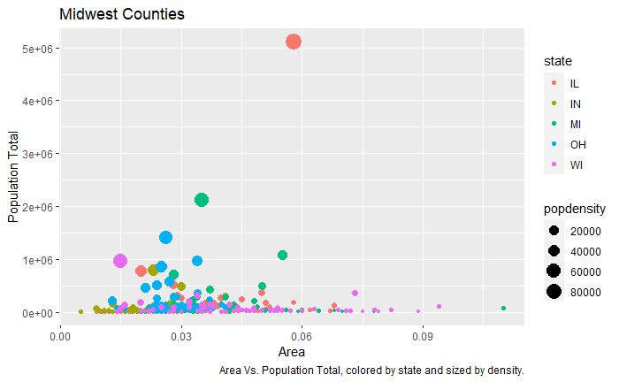

```r
midwest %>%
  ggplot(aes(x = area, y = poptotal, color = state, size = popdensity)) +
  geom_point() +
  labs(title = "Midwest Counties",
       caption = "Area Vs. Population Total, colored by state and sized by density.",
       y = "Population Total",
       x = "Area")
```

4. How would you limit the range of the variables `area` to the interval $[0, 0.1]$ and `poptotal` to $[0, 500000]$.? Comment on your results.

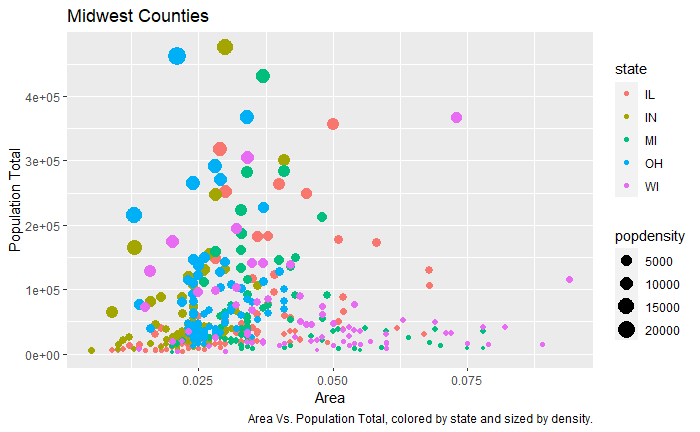

```r
midwest %>%
  filter(area <= 0.1, poptotal <= 500000) %>%
  ggplot(aes(x = area, y = poptotal, color = state, size = popdensity)) +
  geom_point() +
  labs(title = "Midwest Counties",
       caption = "Area Vs. Population Total, colored by state and sized by density.",
       y = "Population Total",
       x = "Area")
```

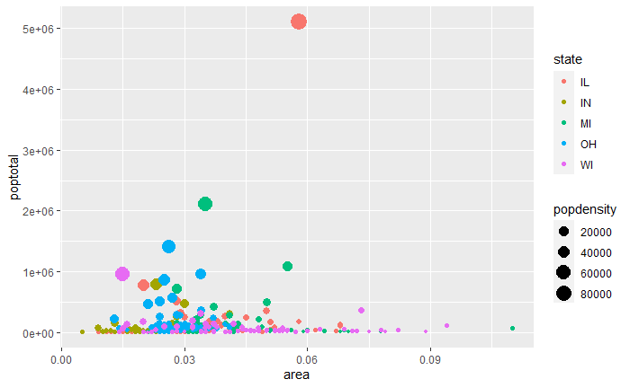

```r
midwest %>%
  ggplot(aes(x = area, y = poptotal, color = state, size = popdensity)) +
  geom_point()
```

Using the `filter` function before piping into `ggplot`, the records plotted fit within the specified range.

5. Create a plot to explore the answer to the question: *Is there a relationship between percent of population below the poverty level (`percbelowpoverty`) and the type of area (`inmetro`)?*

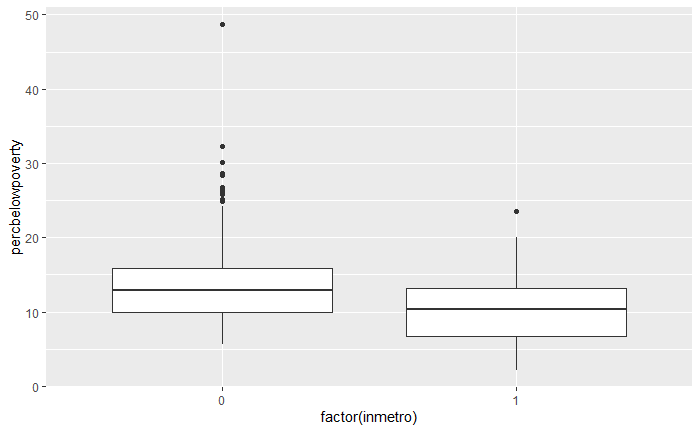

```r
midwest %>%
  ggplot(aes(x = factor(inmetro), y = percbelowpoverty)) +
  geom_boxplot()
```

The boxplot above suggests that counties where `inmetro == 0` have a higher `percbelowpoverty` on average, and both the 1st and 3rd quartiles are placed higher than the corresponding values where `intmetro == 1`. Additionally, there are more outliers present where `inmetro == 0`. Loosely, this visualization would suggest that counties that are not in metro have a higher percentage of people below the poverty line.

# Problem 3

Load the `gapminder` package

```r
library(gapminder)
```

```r
summary(gapminder)
```

```
        country        continent        year         lifeExp           pop              gdpPercap
 Afghanistan:  12   Africa  :624   Min.   :1952   Min.   :23.60   Min.   :6.001e+04   Min.   :   241.2
 Albania    :  12   Americas:300   1st Qu.:1966   1st Qu.:48.20   1st Qu.:2.794e+06   1st Qu.:  1202.1
 Algeria    :  12   Asia    :396   Median :1980   Median :60.71   Median :7.024e+06   Median :  3531.8
 Angola     :  12   Europe  :360   Mean   :1980   Mean   :59.47   Mean   :2.960e+07   Mean   :  7215.3
 Argentina  :  12   Oceania : 24   3rd Qu.:1993   3rd Qu.:70.85   3rd Qu.:1.959e+07   3rd Qu.:  9325.5
 Australia  :  12                  Max.   :2007   Max.   :82.60   Max.   :1.319e+09   Max.   :113523.1
 (Other)    :1632
```

> if you have not installed this yet, make sure you install it, by typing `install.packages("gapminder")` in the `Console`, or using the `Install` button in the `Packages` tab in RStudio
1. Recreate the scatterplot (with the linear fit) shown in [Figure 3.13](https://socviz.co/makeplot.html#makeplot) of Kieran Healy’s Data Visualization book:

[figure not shown]

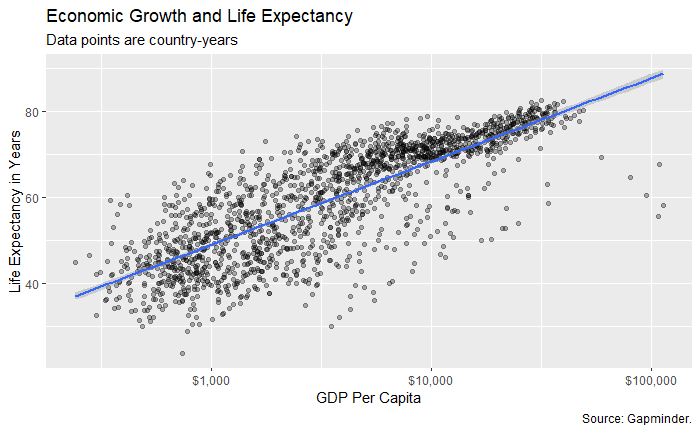

```r
#derived from textbook
p <- ggplot(data = gapminder, mapping = aes(x = gdpPercap, y=lifeExp))
p + geom_point(alpha = 0.3) +
    geom_smooth(method = "lm") +
    scale_x_log10(labels = scales::dollar) +
    labs(x = "GDP Per Capita", y = "Life Expectancy in Years",
         title = "Economic Growth and Life Expectancy",
         subtitle = "Data points are country-years",
         caption = "Source: Gapminder.")
```

2. Is the figure above the best way to display this country-year data? What are we gaining and losing by ignoring the temporal and country-level structure of the data?

I think that this is a reasonably effective display of this country-year data when trying to evaluate how GDP Per Capita affects Life Expectancy. We can see that there is a strong positive trend in this format, but one major aspect we are losing by ignoring the temporal aspect is that some countries may have been increasing Life Expectancy over time for reason(s) unrelated to GDP Per Capita, so that information is lost here.

3. Pick 6 countries of your choice included in the `gapminder` dataset. Create a plot with life expectancy in years in the vertical axis, and GDP per capita in the horizontal axes. For each country include a regression line (`method = "lm"` in `geom_smooth()`). *Comment on your results.*

```r
unique(gapminder$country)
```

```
  [1] Afghanistan              Albania                  Algeria                  Angola
  [5] Argentina                Australia                Austria                  Bahrain
  [9] Bangladesh               Belgium                  Benin                    Bolivia
 [13] Bosnia and Herzegovina   Botswana                 Brazil                   Bulgaria
 [17] Burkina Faso             Burundi                  Cambodia                 Cameroon
 [21] Canada                   Central African Republic Chad                     Chile
 [25] China                    Colombia                 Comoros                  Congo, Dem. Rep.
 [29] Congo, Rep.              Costa Rica               Cote d'Ivoire            Croatia
 [33] Cuba                     Czech Republic           Denmark                  Djibouti
 [37] Dominican Republic       Ecuador                  Egypt                    El Salvador
 [41] Equatorial Guinea        Eritrea                  Ethiopia                 Finland
 [45] France                   Gabon                    Gambia                   Germany
 [49] Ghana                    Greece                   Guatemala                Guinea
 [53] Guinea-Bissau            Haiti                    Honduras                 Hong Kong, China
 [57] Hungary                  Iceland                  India                    Indonesia
```

[output cut: 22 more lines]

```r
countries <- c("United States", "Canada", "China", "Japan", "Sweden", "South Africa")
```

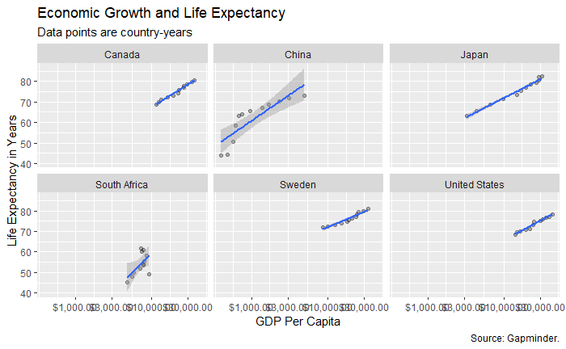

```r
p <- ggplot(data = filter(gapminder, country %in% countries), mapping = aes(x = gdpPercap, y=lifeExp))
p + geom_point(alpha = 0.3) +
    facet_wrap(~country) +
    geom_smooth(method = "lm") +
    scale_x_log10(labels = scales::dollar) +
    labs(x = "GDP Per Capita", y = "Life Expectancy in Years",
         title = "Economic Growth and Life Expectancy",
         subtitle = "Data points are country-years",
         caption = "Source: Gapminder.")
```

After splitting up the visualization by my six selected countries, all are still showing a similar trend as presented previously. In each country, Life Expectancy appears to increase as GDP Per Capita increases. Additionally, it is easier to see how each individual country’s GDP and Life Expectancy change over time.

# Problem 4

In this problem, you will use the `BostonHousing.csv` dataset available [here](https://github.com/reisanar/datasets/blob/master/BostonHousing.csv). It contains information concerning housing in the area of Boston, Massachusetts. The dataset includes information on 506 census housing tracts in the Boston area.

| Variables | Description |
| --- | --- |
| `CRIM` | Crime rate |
| `ZN` | Percentage of residential land zoned for lots over 25,000 ft2 |
| `INDUS` | Percentage of land occupied by non-retail business |
| `CHAS` | Does tract bound Charles River (`= 1` if tract bounds river, `= 0` otherwise) |
| `NOX` | Nitric oxide concentration (parts per 10 million) |
| `RM` | Average number of rooms per dwelling |
| `AGE` | Percentage of owner-occupied units built prior to 1940 |
| `DIS` | Weighted distances to five Boston employment centers |
| `RAD` | Index of accessibility to radial highways |
| `TAX` | Full-value property tax rate per $10,000 |
| `PTRATIO` | Pupil-to-teacher ratio by town |
| `LSTAT` | Percentage of lower status of the population |
| `MEDV` | Median value of owner-occupied homes in $1000s |
| `CAT_MEDV` | Is median value of owner-occupied homes in tract above $30,000 (`CAT.MEDV = 1`) or not (`CAT_MEDV = 0`) |

1. Read the dataset and produce *at least one* data summary of it (e.g. what is the variance and mean of every numerical attribute available?, what is the correlation between `PTRATIO` and `MEDV`?, etc.)

```r
# read the data
housing <- read_csv("https://raw.githubusercontent.com/reisanar/datasets/master/BostonHousing.csv")
```

```r
library(vtable)
st(housing, out = "kable")
```

Summary Statistics

| Variable | N | Mean | Std. Dev. | Min | Pctl. 25 | Pctl. 75 | Max |
| --- | --- | --- | --- | --- | --- | --- | --- |
| CRIM | 506 | 3.614 | 8.602 | 0.006 | 0.082 | 3.677 | 88.976 |
| ZN | 506 | 11.364 | 23.322 | 0 | 0 | 12.5 | 100 |
| INDUS | 506 | 11.137 | 6.86 | 0.46 | 5.19 | 18.1 | 27.74 |
| CHAS | 506 | 0.069 | 0.254 | 0 | 0 | 0 | 1 |
| NOX | 506 | 0.555 | 0.116 | 0.385 | 0.449 | 0.624 | 0.871 |
| RM | 506 | 6.285 | 0.703 | 3.561 | 5.886 | 6.624 | 8.78 |
| AGE | 506 | 68.575 | 28.149 | 2.9 | 45.025 | 94.075 | 100 |
| DIS | 506 | 3.795 | 2.106 | 1.13 | 2.1 | 5.188 | 12.126 |
| RAD | 506 | 9.549 | 8.707 | 1 | 4 | 24 | 24 |
| TAX | 506 | 408.237 | 168.537 | 187 | 279 | 666 | 711 |
| PTRATIO | 506 | 18.456 | 2.165 | 12.6 | 17.4 | 20.2 | 22 |
| LSTAT | 506 | 12.653 | 7.141 | 1.73 | 6.95 | 16.955 | 37.97 |
| MEDV | 506 | 22.533 | 9.197 | 5 | 17.025 | 25 | 50 |
| CAT_MEDV | 506 | 0.166 | 0.372 | 0 | 0 | 0 | 1 |

2. Produce one data visualization to explore this dataset. Comment on your results.

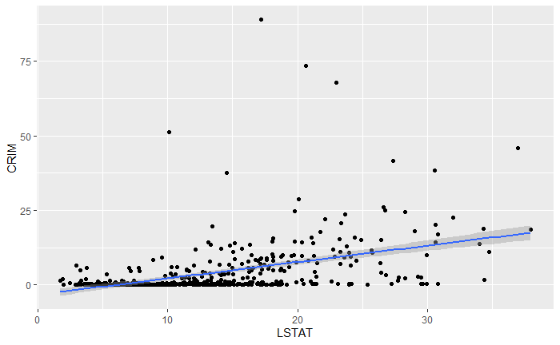

```r
housing %>%
  ggplot(aes(x = LSTAT, y = CRIM)) +
  geom_point() +
  geom_smooth(method = "lm")
```

The simple visualization above plots the relationship between `LSTAT` and `CRIM`, or percent lower status of the population vs. per capita crime rate by down. The linear regression line suggests there may be a positive relationship between these two variables.